# Risk Factor Analysis

## Outcome Variable

**Outcome Variable:** haz

## Predictor Variables

**Intervention Variable:** month

**Adjustment Set:**

unadjusted

## Stratifying Variables

The analysis was stratified on these variable(s):

- agecat

## Data Summary

| agecat | month | n_cell | n | outcome_variable |
| --- | --- | --- | --- | --- |
| Birth | 1 | 4776 | 58786 | haz |
| Birth | 2 | 4370 | 58786 | haz |
| Birth | 3 | 5013 | 58786 | haz |
| Birth | 4 | 4314 | 58786 | haz |
| Birth | 5 | 3829 | 58786 | haz |
| Birth | 6 | 4125 | 58786 | haz |
| Birth | 7 | 4701 | 58786 | haz |
| Birth | 8 | 5179 | 58786 | haz |
| Birth | 9 | 5464 | 58786 | haz |
| Birth | 10 | 5495 | 58786 | haz |
| Birth | 11 | 5555 | 58786 | haz |
| Birth | 12 | 5965 | 58786 | haz |
| 6 months | 1 | 4347 | 57686 | haz |
| 6 months | 2 | 3907 | 57686 | haz |
| 6 months | 3 | 4618 | 57686 | haz |
| 6 months | 4 | 4676 | 57686 | haz |
| 6 months | 5 | 4345 | 57686 | haz |
| 6 months | 6 | 4369 | 57686 | haz |
| 6 months | 7 | 5175 | 57686 | haz |
| 6 months | 8 | 5285 | 57686 | haz |
| 6 months | 9 | 5146 | 57686 | haz |
| 6 months | 10 | 5220 | 57686 | haz |
| 6 months | 11 | 5216 | 57686 | haz |
| 6 months | 12 | 5382 | 57686 | haz |
| 24 months | 1 | 1707 | 25128 | haz |
| 24 months | 2 | 1865 | 25128 | haz |
| 24 months | 3 | 2156 | 25128 | haz |
| 24 months | 4 | 2320 | 25128 | haz |
| 24 months | 5 | 1910 | 25128 | haz |
| 24 months | 6 | 1952 | 25128 | haz |
| 24 months | 7 | 2537 | 25128 | haz |
| 24 months | 8 | 2192 | 25128 | haz |
| 24 months | 9 | 1954 | 25128 | haz |
| 24 months | 10 | 2020 | 25128 | haz |
| 24 months | 11 | 2088 | 25128 | haz |
| 24 months | 12 | 2427 | 25128 | haz |

The following strata were considered:

- agecat: 24 months
- agecat: 6 months
- agecat: Birth

## Methods Detail

We’re interested in the causal parameters $E[Y_a]$ for all values of $a \in \mathcal{A}$. These parameters represent the mean outcome if, possibly contrary to fact, we intervened to set all units to have $A=a$. Under the randomization and positivity assumptions, these are identified by the statistical parameters $\psi_a=E_W[E_{Y|A,W}(Y|A=a,W)]$. In addition, we’re interested in the mean of $Y$, $E[Y]$ under no intervention (the observed mean). We will estimate these parameters by using SuperLearner to fit the relevant likelihood factors – $E_{Y|A,W}(Y|A=a,W)$ and $p(A=a|W)$, and then updating our likelihood fit using a joint TMLE.

For unadjusted analyses ($W=\{\}$), initial likelihoods were estimated using Lrnr_glm to estimate the simple $E(Y|A)$ and Lrnr_mean to estimate $p(A)$. For adjusted analyses, a small library containing Lrnr_glmnet, Lrnr_xgboost, and Lrnr_mean was used.

Having estimated these parameters, we will then use the delta method to estimate relative risks and attributable risks relative to a prespecified baseline level of $A$.

# Results Detail

## Results Plots

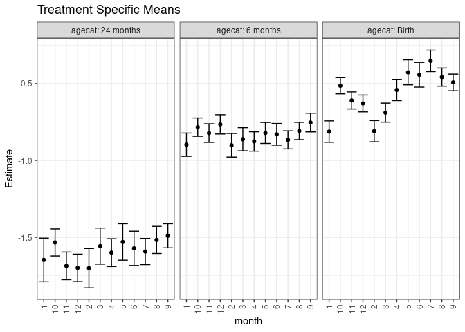

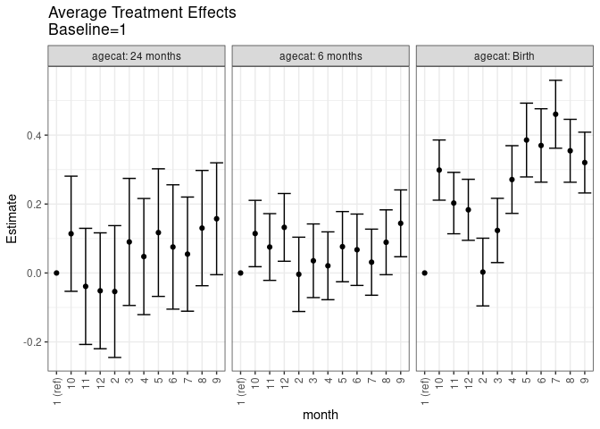

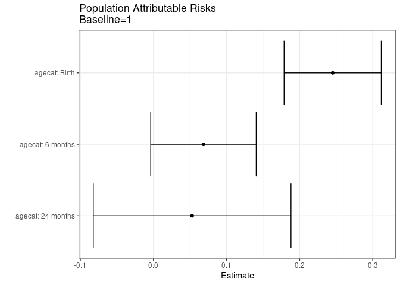

## Results Table

### Parameter: TSM

| agecat | intervention_level | baseline_level | estimate | ci_lower | ci_upper |
| --- | --- | --- | --- | --- | --- |
| Birth | 1 | NA | -0.8122529 | -0.8819787 | -0.7425272 |
| Birth | 2 | NA | -0.8095858 | -0.8789109 | -0.7402608 |
| Birth | 3 | NA | -0.6888650 | -0.7508197 | -0.6269102 |
| Birth | 4 | NA | -0.5411590 | -0.6104915 | -0.4718266 |
| Birth | 5 | NA | -0.4264926 | -0.5078594 | -0.3451257 |
| Birth | 6 | NA | -0.4423273 | -0.5228870 | -0.3617676 |
| Birth | 7 | NA | -0.3516571 | -0.4213928 | -0.2819214 |
| Birth | 8 | NA | -0.4576559 | -0.5167271 | -0.3985847 |
| Birth | 9 | NA | -0.4918695 | -0.5459336 | -0.4378054 |
| Birth | 10 | NA | -0.5136742 | -0.5663137 | -0.4610348 |
| Birth | 11 | NA | -0.6093951 | -0.6649410 | -0.5538492 |
| Birth | 12 | NA | -0.6289732 | -0.6837373 | -0.5742090 |
| 6 months | 1 | NA | -0.8974836 | -0.9731390 | -0.8218282 |
| 6 months | 2 | NA | -0.9013780 | -0.9782107 | -0.8245453 |
| 6 months | 3 | NA | -0.8620494 | -0.9374335 | -0.7866653 |
| 6 months | 4 | NA | -0.8766008 | -0.9396821 | -0.8135196 |
| 6 months | 5 | NA | -0.8210976 | -0.8894955 | -0.7526996 |
| 6 months | 6 | NA | -0.8300773 | -0.9007334 | -0.7594213 |
| 6 months | 7 | NA | -0.8661641 | -0.9250710 | -0.8072572 |
| 6 months | 8 | NA | -0.8084408 | -0.8647753 | -0.7521064 |
| 6 months | 9 | NA | -0.7534060 | -0.8141662 | -0.6926458 |
| 6 months | 10 | NA | -0.7830255 | -0.8426278 | -0.7234231 |
| 6 months | 11 | NA | -0.8221452 | -0.8826545 | -0.7616359 |
| 6 months | 12 | NA | -0.7651268 | -0.8279553 | -0.7022984 |
| 24 months | 1 | NA | -1.6471192 | -1.7891585 | -1.5050800 |
| 24 months | 2 | NA | -1.7009664 | -1.8292646 | -1.5726682 |
| 24 months | 3 | NA | -1.5570041 | -1.6744558 | -1.4395524 |
| 24 months | 4 | NA | -1.5995040 | -1.6901239 | -1.5088840 |
| 24 months | 5 | NA | -1.5299459 | -1.6486793 | -1.4112125 |
| 24 months | 6 | NA | -1.5716638 | -1.6833048 | -1.4600229 |
| 24 months | 7 | NA | -1.5923986 | -1.6775677 | -1.5072295 |
| 24 months | 8 | NA | -1.5168438 | -1.6052164 | -1.4284713 |
| 24 months | 9 | NA | -1.4897980 | -1.5682819 | -1.4113141 |
| 24 months | 10 | NA | -1.5332271 | -1.6212925 | -1.4451617 |
| 24 months | 11 | NA | -1.6860087 | -1.7762727 | -1.5957447 |
| 24 months | 12 | NA | -1.6987941 | -1.7881137 | -1.6094745 |

### Parameter: E(Y)

| agecat | intervention_level | baseline_level | estimate | ci_lower | ci_upper |
| --- | --- | --- | --- | --- | --- |
| Birth | NA | NA | -0.5670272 | -0.5856665 | -0.5483879 |
| 6 months | NA | NA | -0.8290210 | -0.8479330 | -0.8101089 |
| 24 months | NA | NA | -1.5941639 | -1.6235772 | -1.5647505 |

### Parameter: ATE

| agecat | intervention_level | baseline_level | estimate | ci_lower | ci_upper |
| --- | --- | --- | --- | --- | --- |
| Birth | 1 | 1 | 0.0000000 | 0.0000000 | 0.0000000 |
| Birth | 2 | 1 | 0.0026671 | -0.0956456 | 0.1009798 |
| Birth | 3 | 1 | 0.1233880 | 0.0301515 | 0.2166244 |
| Birth | 4 | 1 | 0.2710939 | 0.1728507 | 0.3693371 |
| Birth | 5 | 1 | 0.3857604 | 0.2787049 | 0.4928159 |
| Birth | 6 | 1 | 0.3699257 | 0.2634302 | 0.4764211 |
| Birth | 7 | 1 | 0.4605958 | 0.3620629 | 0.5591288 |
| Birth | 8 | 1 | 0.3545970 | 0.2633312 | 0.4458628 |
| Birth | 9 | 1 | 0.3203834 | 0.2322125 | 0.4085543 |
| Birth | 10 | 1 | 0.2985787 | 0.2113022 | 0.3858551 |
| Birth | 11 | 1 | 0.2028578 | 0.1137914 | 0.2919241 |
| Birth | 12 | 1 | 0.1832798 | 0.0947042 | 0.2718553 |
| 6 months | 1 | 1 | 0.0000000 | 0.0000000 | 0.0000000 |
| 6 months | 2 | 1 | -0.0038944 | -0.1117352 | 0.1039464 |
| 6 months | 3 | 1 | 0.0354342 | -0.0714448 | 0.1423132 |
| 6 months | 4 | 1 | 0.0208827 | -0.0775055 | 0.1192709 |
| 6 months | 5 | 1 | 0.0763860 | -0.0254684 | 0.1782404 |
| 6 months | 6 | 1 | 0.0674063 | -0.0361200 | 0.1709325 |
| 6 months | 7 | 1 | 0.0313195 | -0.0645538 | 0.1271928 |
| 6 months | 8 | 1 | 0.0890428 | -0.0050605 | 0.1831460 |
| 6 months | 9 | 1 | 0.1440776 | 0.0471259 | 0.2410292 |
| 6 months | 10 | 1 | 0.1144581 | 0.0182349 | 0.2106813 |
| 6 months | 11 | 1 | 0.0753384 | -0.0214812 | 0.1721581 |
| 6 months | 12 | 1 | 0.1323567 | 0.0340523 | 0.2306612 |
| 24 months | 1 | 1 | 0.0000000 | 0.0000000 | 0.0000000 |
| 24 months | 2 | 1 | -0.0538472 | -0.2451145 | 0.1374201 |
| 24 months | 3 | 1 | 0.0901151 | -0.0942328 | 0.2744631 |
| 24 months | 4 | 1 | 0.0476153 | -0.1208276 | 0.2160581 |
| 24 months | 5 | 1 | 0.1171733 | -0.0679046 | 0.3022512 |
| 24 months | 6 | 1 | 0.0754554 | -0.1049542 | 0.2558650 |
| 24 months | 7 | 1 | 0.0547206 | -0.1108703 | 0.2203116 |
| 24 months | 8 | 1 | 0.1302754 | -0.0369469 | 0.2974977 |
| 24 months | 9 | 1 | 0.1573212 | -0.0050253 | 0.3196677 |
| 24 months | 10 | 1 | 0.1138922 | -0.0531706 | 0.2809549 |
| 24 months | 11 | 1 | -0.0388895 | -0.2073474 | 0.1295684 |
| 24 months | 12 | 1 | -0.0516749 | -0.2198118 | 0.1164620 |

### Parameter: PAR

| agecat | intervention_level | baseline_level | estimate | ci_lower | ci_upper |
| --- | --- | --- | --- | --- | --- |
| Birth | 1 | NA | 0.2452257 | 0.1787580 | 0.3116934 |
| 6 months | 1 | NA | 0.0684626 | -0.0037007 | 0.1406260 |
| 24 months | 1 | NA | 0.0529553 | -0.0822884 | 0.1881991 |